# Multiple Linear Regression

Sazykin Dmitry

2 октября 2017 г

## CITY

Данные – города. Признаки:

```r
names(df)
```

```
##  [1] "CITY"   "AREA"   "POP80"  "POP92"  "POPDEN" "BORN_F" "CRIME"
##  [8] "INCOME" "POVERT" "TEMPER" "UNEMP"
```

- CITY – Название города
- AREA – Площадь
- POP80/POP92 – Население города в 1980/1992 г
- POPDEN – Плотность
- BORN_F – Процент иностранных граждан
- CRIME – Уровень преступности на 100000 человек, 1991
- INCOME – Средний доход семьи, 1989
- POVERT – Процент лиц ниже уровня бедности, 1989
- TEMPER – Cредняя дневная температура в июле
- UNEMP – Процент безработных, 1991

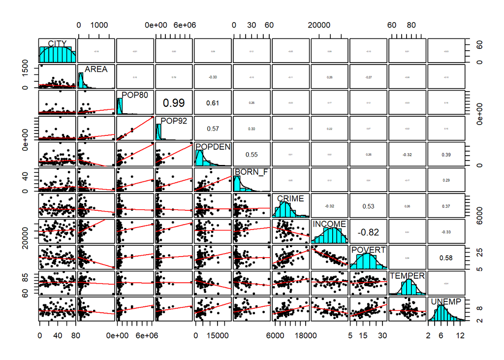

Преобразуем признаки и уберем аутлаеры. Итоговый результат

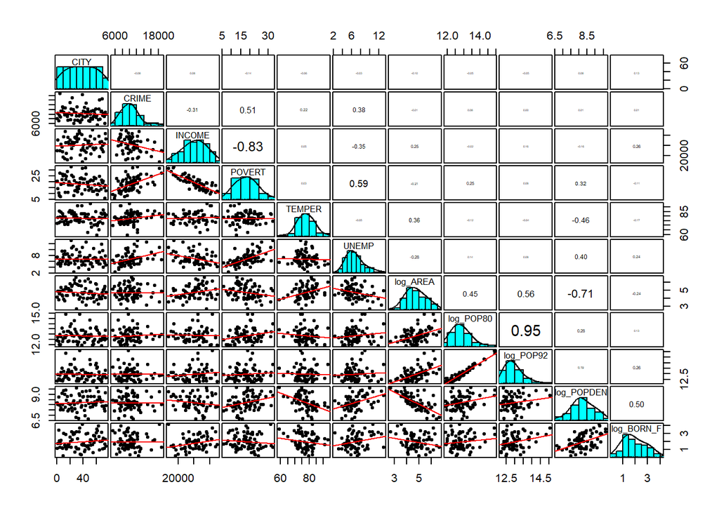

```r
summary(df_city[,-1])
```

```
##      CRIME           INCOME          POVERT          TEMPER
##  Min.   : 5364   Min.   :16925   Min.   : 5.90   Min.   :59.10
##  1st Qu.: 8560   1st Qu.:22674   1st Qu.:13.40   1st Qu.:73.50
##  Median :10028   Median :25592   Median :18.10   Median :77.90
##  Mean   :10321   Mean   :25213   Mean   :18.10   Mean   :77.61
##  3rd Qu.:11360   3rd Qu.:28024   3rd Qu.:22.05   3rd Qu.:82.05
##  Max.   :18953   Max.   :32451   Max.   :32.40   Max.   :93.50
##  NA's   :1       NA's   :10
##      UNEMP           log_AREA       log_POP80       log_POP92
##  Min.   : 2.300   Min.   :2.701   Min.   :11.91   Min.   :12.22
##  1st Qu.: 5.350   1st Qu.:4.121   1st Qu.:12.39   1st Qu.:12.52
##  Median : 6.400   Median :4.688   Median :12.79   Median :12.86
##  Mean   : 6.811   Mean   :4.742   Mean   :12.87   Mean   :12.98
##  3rd Qu.: 7.700   3rd Qu.:5.232   3rd Qu.:13.24   3rd Qu.:13.21
##  Max.   :13.100   Max.   :6.632   Max.   :14.92   Max.   :15.07
##
##    log_POPDEN      log_BORN_F
##  Min.   :6.615   Min.   :0.1823
##  1st Qu.:7.807   1st Qu.:1.2238
##  Median :8.174   Median :1.8083
##  Mean   :8.233   Mean   :1.9413
##  3rd Qu.:8.775   3rd Qu.:2.6791
##  Max.   :9.656   Max.   :4.0893
##
```

## Построение линейной регрессии

Проведем регрессию CRIME на остальные признаки. Так как у нас имеются сильно коррелированные признаки POP80 и POP92, Возьмем только один из них.

В наблюдениях имеются NA, а для построения регрессии нам необходимо отсутствие пропусков, поэтому рассмотрим два варианта регрессии.

### Casewise

```
##
## Call:
## lm(formula = CRIME ~ ., data = df_1)
##
## Residuals:
##     Min      1Q  Median      3Q     Max
## -4622.6 -1463.1  -523.7  1208.8  7013.6
##
## Coefficients:
##               Estimate Std. Error t value Pr(>|t|)
## (Intercept)  1.136e+04  1.186e+04   0.958   0.3422
## INCOME      -5.127e-02  1.879e-01  -0.273   0.7860
## POVERT       1.919e+02  1.451e+02   1.322   0.1915
## TEMPER       6.579e+01  6.179e+01   1.065   0.2917
## UNEMP        1.262e+02  2.107e+02   0.599   0.5516
## log_AREA    -1.127e+06  2.282e+06  -0.494   0.6233
## log_POP92    1.127e+06  2.282e+06   0.494   0.6234
## log_POPDEN  -1.128e+06  2.281e+06  -0.494   0.6230
## log_BORN_F   9.296e+02  4.977e+02   1.868   0.0671 .
## ---
## Signif. codes:  0 '***' 0.001 '**' 0.01 '*' 0.05 '.' 0.1 ' ' 1
##
## Residual standard error: 2471 on 55 degrees of freedom
## Multiple R-squared:  0.2901, Adjusted R-squared:  0.1869
## F-statistic:  2.81 on 8 and 55 DF,  p-value: 0.01099
```

Рассматриваемые обозначения
$$\sum_{i=1}^n(y_i-\bar{y})^2 =\sum_{i=1}^n(\bar{y}-\widehat{y}_i)^2 + \sum_{i=1}^n(y_i-\widehat{y}_i)^2$$
$$\text{TSS}=\text{ESS}+\text{RSS}$$

Для начала рассмотрим блок Coefficients. Строка Intercept отвечает за свободный член, Estimate это значения $\widehat{b}$, Standart Error. Далее идет проверка гипотезы о равенстве нулю коэффициентов со статистикой критерия (имеет распределение Стьюдента при верной $H_0$)
$$t_i=\dfrac{\widehat{b}_i-0}{\sqrt{\mathrm{D}\widehat{b}_i}} = \sqrt{n}\dfrac{\widehat{b}_i}{\widehat{\sigma}(\mathbf{S}_{xx}^{-1})^{1/2}_{ii}}\sim t(n-m),\;\;\widehat{\sigma}=\dfrac{\text{RSS}}{n-m}=\dfrac{\sum_{i=1}^n(y_i-\widehat{y}_i)^2}{n-m}.$$

Ниже рассматривается гипотеза $H_0: \mathbf{b}=0$ со статистикой критерия
$$t=r^2_M(\mathbf{\widehat{b},0};\text{SE}(\mathbf{\widehat{b}}))\sim \text{F}(m-1,n-m),$$
при верной $H_0$. Оказывается, что
$$R^2=\dfrac{\text{ESS}}{\text{TSS}}=1-\dfrac{\text{RSS}}{\text{TSS}} ,$$

$$\text{adjusted}\,R^2 =1-\dfrac{\text{RSS}/(n-m)}{\text{TSS}/(n-1)}$$
и можно переписать
$$t=\dfrac{R^2/(m-1)}{(1-R^2)/(n-m)}.$$

### Проблема зависимых “независимых” признаков

Проблемы коррелированых признаков

1. Дисперсия оценок коэффициентов регрессии стремится к бесконечности
2. Сложно интерпретировать вклад каждого признака

Пример. Пусть $\eta=\beta_1\xi_1+\beta_2\xi_2$. Пусть
$$\mathbf{X}^\mathrm{T}\mathbf{X}= n\begin{pmatrix}
1 & \rho\\
\rho & 1
\end{pmatrix}.$$

$$\text{cov}\widehat{\beta}=\sigma^2(\mathbf{X}^\mathrm{T}\mathbf{X})^{-1} = \dfrac{\sigma^2}{n(1-\rho^2)} \begin{pmatrix}
1 & -\rho\\
-\rho & 1
\end{pmatrix}\Rightarrow\, \mathrm{D}\widehat{b}_i \xrightarrow[\rho\rightarrow 1]{}\infty .$$

Для отсеивания лишних признаков рассмотим следующие параметры.

1. Множественный коэффициент корреляции $R^2(\xi_i;\{\xi_j, j\neq i\})$.
   $$\mathrm{D}\widehat{b}_i\sim\dfrac{1}{1-R^2(\xi_i;\{\xi_j, j\neq i\})}.$$

Чем больше значение $R^2$, тем выше дисперсия.

2. Частные корреляции $\rho(\xi_i,\eta|\{\xi_j, j\neq i\})$. По смыслу, чем выше данная корреляция, тем больше вклад признака в регрессию.

Таким образом постараемся уменьшить количество признаков на основе данных корреляций.

```
##        names      r.sq       p.cor
## 1     INCOME 0.8097120 -0.03676157
## 2     POVERT 0.8414015  0.17555625
## 3     TEMPER 0.2754311  0.14209966
## 4      UNEMP 0.5332746  0.08051181
## 5   log_AREA 1.0000000 -0.06645268
## 6  log_POP92 0.9999999  0.06643329
## 7 log_POPDEN 1.0000000 -0.06650815
## 8 log_BORN_F 0.4589695  0.24420837
```

log_AREA и log_POPDEN наиболее предпочтительны для удаления, однако между ними существует сильная корреляция, поэтому не будем спешить выкидывать сразу оба признака и выкинем только log_AREA.

```r
my_func(df_1[,-6])
```

```
##        names      r.sq       p.cor
## 1     INCOME 0.8097092 -0.03642854
## 2     POVERT 0.8412661  0.17339833
## 3     TEMPER 0.2301064  0.12992033
## 4      UNEMP 0.5199547  0.09256455
## 5  log_POP92 0.1499126 -0.07243813
## 6 log_POPDEN 0.4875385 -0.19357725
## 7 log_BORN_F 0.4586026  0.24535595
```

Как видно, значения $R^2$ явно уменьшились. Следущим на удаление - INCOME

```r
my_func(df_1[,-c(6,2)])
```

```
##        names       r.sq       p.cor
## 1     POVERT 0.44840694  0.35953473
## 2     TEMPER 0.22981594  0.13054931
## 3      UNEMP 0.50422305  0.08748069
## 4  log_POP92 0.07652365 -0.08603219
## 5 log_POPDEN 0.48741404 -0.19401227
## 6 log_BORN_F 0.36969437  0.24994695
```

Следующим удалим log_POP92 из-за малого вклада в регрессию

```r
my_func(df_1[,-c(6,7,2)])
```

```
##        names      r.sq       p.cor
## 1     POVERT 0.4462848  0.35462278
## 2     TEMPER 0.2250305  0.12385246
## 3      UNEMP 0.5017923  0.09332094
## 4 log_POPDEN 0.4867923 -0.19625996
## 5 log_BORN_F 0.3376138  0.23726375
```

Выкидываем UNEMP.

```r
my_func(df_1[,-c(6,7,2,5)])
```

```
##        names      r.sq      p.cor
## 1     POVERT 0.1799039  0.4643377
## 2     TEMPER 0.2250285  0.1231759
## 3 log_POPDEN 0.4757048 -0.1844818
## 4 log_BORN_F 0.2584341  0.2781353
```

```r
cut_model <- lm(CRIME~POVERT+TEMPER+log_POPDEN+log_BORN_F,df_1)
summary(cut_model)
```

```
##
## Call:
## lm(formula = CRIME ~ POVERT + TEMPER + log_POPDEN + log_BORN_F,
##     data = df_1)
##
## Residuals:
##     Min      1Q  Median      3Q     Max
## -4551.6 -1418.3  -719.6  1358.3  6515.1
##
## Coefficients:
##             Estimate Std. Error t value Pr(>|t|)
## (Intercept)  7253.51    7681.63   0.944 0.348884
## POVERT        250.85      62.29   4.027 0.000164 ***
## TEMPER         55.61      58.32   0.953 0.344281
## log_POPDEN   -896.34     621.69  -1.442 0.154652
## log_BORN_F    923.02     415.00   2.224 0.029977 *
## ---
## Signif. codes:  0 '***' 0.001 '**' 0.01 '*' 0.05 '.' 0.1 ' ' 1
##
## Residual standard error: 2412 on 59 degrees of freedom
## Multiple R-squared:  0.2744, Adjusted R-squared:  0.2252
## F-statistic: 5.578 on 4 and 59 DF,  p-value: 0.0007068
```

Как видно, на этом останавливаться пока рано.

Уберем TEMPER.

```r
my_func(df_1[,-c(6,7,2,5,4)])
```

```
##        names      r.sq      p.cor
## 1     POVERT 0.1646082  0.4764720
## 2 log_POPDEN 0.3273192 -0.2665205
## 3 log_BORN_F 0.2145930  0.3096688
```

На этом результате можно уже остановиться.

```r
cut_model <- lm(CRIME~POVERT+log_POPDEN+log_BORN_F,df_1)
summary(cut_model)
```

```
##
## Call:
## lm(formula = CRIME ~ POVERT + log_POPDEN + log_BORN_F, data = df_1)
##
## Residuals:
##    Min     1Q Median     3Q    Max
##  -4639  -1540   -512   1312   6481
##
## Coefficients:
##             Estimate Std. Error t value Pr(>|t|)
## (Intercept) 13563.55    3896.10   3.481 0.000937 ***
## POVERT        258.89      61.67   4.198 9.05e-05 ***
## log_POPDEN  -1174.72     548.44  -2.142 0.036268 *
## log_BORN_F   1016.50     402.94   2.523 0.014316 *
## ---
## Signif. codes:  0 '***' 0.001 '**' 0.01 '*' 0.05 '.' 0.1 ' ' 1
##
## Residual standard error: 2410 on 60 degrees of freedom
## Multiple R-squared:  0.2632, Adjusted R-squared:  0.2264
## F-statistic: 7.145 on 3 and 60 DF,  p-value: 0.0003508
```

Коэффициенты регрессии стали значимы, adjusted $R^2$ даже увеличился, p-value на порядок уменьшился.

Помимо ручного уменьшения количества признаков, воспользуемся stepwise алгоритмом на основе AIC. В данном случае требуется нормальность признаков, в противном случае результат не обоснован.

```
## Start:  AIC=1008.3
## CRIME ~ INCOME + POVERT + TEMPER + UNEMP + log_AREA + log_POP92 +
##     log_POPDEN + log_BORN_F
##
##              Df Sum of Sq       RSS    AIC
## - INCOME      1    454519 336328643 1006.4
## - log_POP92   1   1488912 337363036 1006.6
## - log_AREA    1   1489785 337363909 1006.6
## - log_POPDEN  1   1492284 337366408 1006.6
## - UNEMP       1   2191392 338065516 1006.7
## - TEMPER      1   6921844 342795968 1007.6
## <none>                    335874124 1008.3
## - POVERT      1  10680822 346554946 1008.3
## - log_BORN_F  1  21301120 357175244 1010.2
##
## Step:  AIC=1006.38
## CRIME ~ POVERT + TEMPER + UNEMP + log_AREA + log_POP92 + log_POPDEN +
##     log_BORN_F
##
##              Df Sum of Sq       RSS    AIC
## - log_POP92   1   1482562 337811205 1004.7
## - log_AREA    1   1483556 337812199 1004.7
## - log_POPDEN  1   1486057 337814700 1004.7
## - UNEMP       1   1914632 338243275 1004.8
## - TEMPER      1   6987795 343316438 1005.7
## <none>                    336328643 1006.4
## + INCOME      1    454519 335874124 1008.3
## - log_BORN_F  1  22149907 358478550 1008.5
## - POVERT      1  51012000 387340643 1013.4
##
## Step:  AIC=1004.66
## CRIME ~ POVERT + TEMPER + UNEMP + log_AREA + log_POPDEN + log_BORN_F
##
##              Df Sum of Sq       RSS    AIC
## - log_AREA    1   2519968 340331173 1003.1
## - UNEMP       1   2604856 340416061 1003.1
## - TEMPER      1   5857754 343668958 1003.8
## <none>                    337811205 1004.7
## - log_POPDEN  1  14613716 352424920 1005.4
## + log_POP92   1   1482562 336328643 1006.4
```

[output cut: 30 more lines]

```
## - POVERT      1  94370428 437691515 1015.2
##
## Step:  AIC=1000.68
## CRIME ~ POVERT + log_POPDEN + log_BORN_F
##
##              Df Sum of Sq       RSS    AIC
## <none>                    348610304 1000.7
## + TEMPER      1   5289217 343321087 1001.7
## + UNEMP       1   2977318 345632986 1002.1
## + log_AREA    1   2305726 346304578 1002.2
## + log_POP92   1   2305034 346305270 1002.2
## + INCOME      1    649281 347961022 1002.6
## - log_POPDEN  1  26656382 375266685 1003.4
## - log_BORN_F  1  36975675 385585979 1005.1
## - POVERT      1 102388165 450998468 1015.2
```

```
##
## Call:
## lm(formula = CRIME ~ POVERT + log_POPDEN + log_BORN_F, data = df_1)
##
## Residuals:
##    Min     1Q Median     3Q    Max
##  -4639  -1540   -512   1312   6481
##
## Coefficients:
##             Estimate Std. Error t value Pr(>|t|)
## (Intercept) 13563.55    3896.10   3.481 0.000937 ***
## POVERT        258.89      61.67   4.198 9.05e-05 ***
## log_POPDEN  -1174.72     548.44  -2.142 0.036268 *
## log_BORN_F   1016.50     402.94   2.523 0.014316 *
## ---
## Signif. codes:  0 '***' 0.001 '**' 0.01 '*' 0.05 '.' 0.1 ' ' 1
##
## Residual standard error: 2410 on 60 degrees of freedom
## Multiple R-squared:  0.2632, Adjusted R-squared:  0.2264
## F-statistic: 7.145 on 3 and 60 DF,  p-value: 0.0003508
```

Информационный критерий AIC: $\text{AIC} = - 2\log L + k * edf$, edf - число параметров модели, $k=2$, для BIC $k=\log(n)$. При увелечении числа параметров модели $\log L$ будет расти, но нам нужно найти баланс между информативностью модели и ее сложностью, поэтому на число параметров накладывается штраф.

В этом случае пришли к той же самой модели CRIME ~ POVERT + log_POPDEN + log_BORN_F. В целом методы backward и forward дают схожий результат, однако метод backward предпочтительней, так как при работе алгоритма возможны промежутки, когда $R^2$ почти не изменяется, но лишние признаки все арвно присутствуют. Both метод на каждом шаге будет рассматривать возможные включения и исключения признаков и является самый предпочтительным вариантом.

Рассмотрим отобранные признаки.

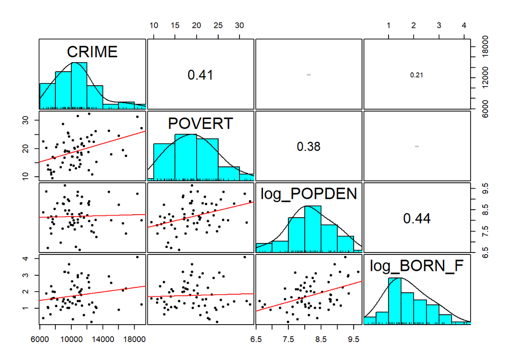

```
##
## Call:
## lm(formula = CRIME ~ ., data = df_2)
##
## Residuals:
##     Min      1Q  Median      3Q     Max
## -4266.5 -1313.7  -483.3   997.1  6736.6
##
## Coefficients:
##               Estimate Std. Error t value Pr(>|t|)
## (Intercept)  6.218e+03  1.012e+04   0.615 0.540945
## POVERT       2.457e+02  6.543e+01   3.755 0.000369 ***
## TEMPER       7.774e+01  5.344e+01   1.455 0.150510
## UNEMP        1.343e+02  1.729e+02   0.777 0.439957
## log_AREA    -1.846e+06  2.026e+06  -0.911 0.365583
## log_POP92    1.845e+06  2.026e+06   0.911 0.365649
## log_POPDEN  -1.846e+06  2.026e+06  -0.911 0.365355
## log_BORN_F   5.672e+02  3.972e+02   1.428 0.157970
## ---
## Signif. codes:  0 '***' 0.001 '**' 0.01 '*' 0.05 '.' 0.1 ' ' 1
##
## Residual standard error: 2366 on 66 degrees of freedom
## Multiple R-squared:  0.3563, Adjusted R-squared:  0.2881
## F-statistic: 5.219 on 7 and 66 DF,  p-value: 9.003e-05
```

Повторим процедуру отсеивания признаков

```
##
## Call:
## lm(formula = CRIME ~ POVERT + log_POPDEN + log_BORN_F, data = df_2)
##
## Residuals:
##     Min      1Q  Median      3Q     Max
## -4318.4 -1321.7  -464.4  1237.8  6130.2
##
## Coefficients:
##             Estimate Std. Error t value Pr(>|t|)
## (Intercept) 13526.02    3624.57   3.732 0.000383 ***
## POVERT        296.49      51.45   5.762 2.05e-07 ***
## log_POPDEN  -1206.36     515.15  -2.342 0.022045 *
## log_BORN_F    702.34     366.93   1.914 0.059696 .
## ---
## Signif. codes:  0 '***' 0.001 '**' 0.01 '*' 0.05 '.' 0.1 ' ' 1
##
## Residual standard error: 2358 on 70 degrees of freedom
## Multiple R-squared:  0.3219, Adjusted R-squared:  0.2928
## F-statistic: 11.08 on 3 and 70 DF,  p-value: 4.901e-06
```

Рассмотрим нормализованные коэффициенты $\beta_i$ для оценки вклада каждого признака.

```r
lm.beta(model_cut_2)
```

```
##     POVERT log_POPDEN log_BORN_F
##  0.6294880 -0.2914494  0.2280448
```

Интерпретация - так как мы нормализовали признаки, то значения коэффициентов $b_i$ и говорят о построенной зависимости.

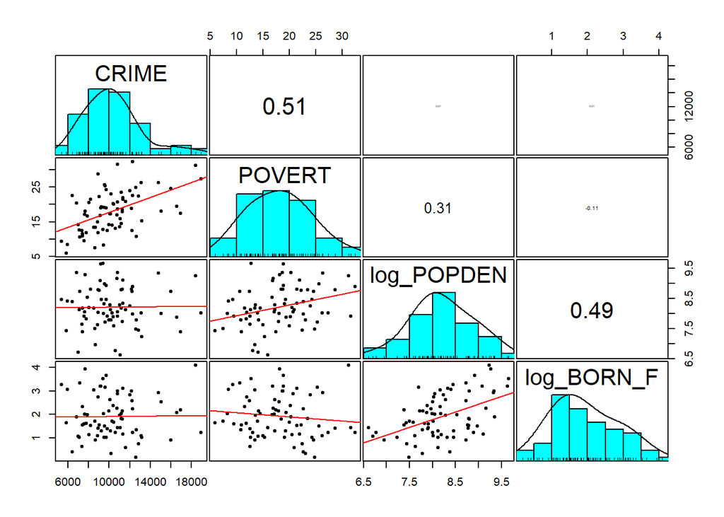

### Нормальность модели

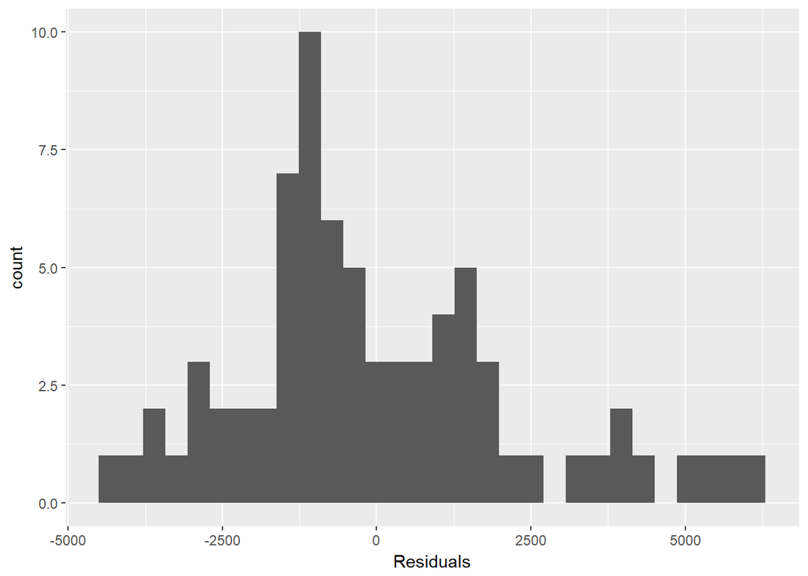

```
##
##  Shapiro-Wilk normality test
##
## data:  model_cut_2$residuals
## W = 0.95541, p-value = 0.01069
```

В случае нормальных остатков имеем точные оценки (доверительные интервалы), иначе имеем только асимптотическую нормальность коэффициентов $b_i$ со всеми вытекающими. В данном случае нормальности нет.

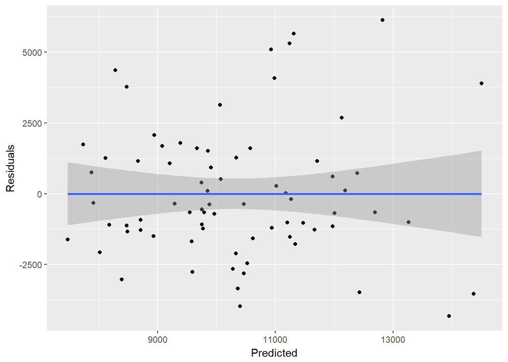

В целом можно говорить об адекватности модели, так как никаких нелинейных зависимостей не наблюдается.

### Поиск outliers

Рассмотрим график. По оси X отложены полученные остатки (residuals) $r_i=y_i-\widehat{y}_i$, по оси Y отложен остаток при построенной модели без данного индивида $r_i^{(i)}=y_i-\widehat{y}_i^{(i)}$. Если индвид является аутлаером, то тогда остаток без него будет больше, чем в модели с его участием. Стандартизированные остатки - потому что нормировали на корень из дисперсии (среднее равно 0), а стьдентизированные, потому что дисперсия неизвестна и подставляется её оценка. Полученная прямая не является $y=x$, так как, по понятным причинам, $r_i^{(i)}\geq r_i$.

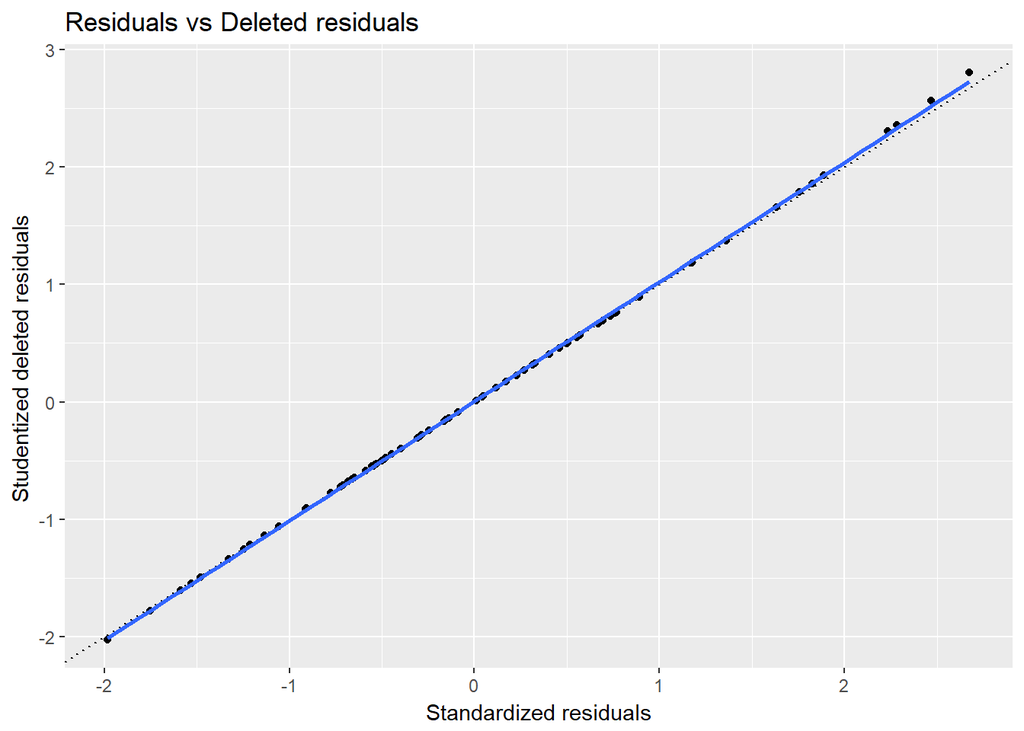

На данном графике outliers не видны.

Аутлаеры по Куку. Рассматривается расстаяние Махаланобиса по ковариационной матрице коэффициентов между вектором коэффициентов и коэффициентами, построенными на множестве без какого-то индивида. Если расстояние велико, то индивид лежит “далеко” от линии регрессии.

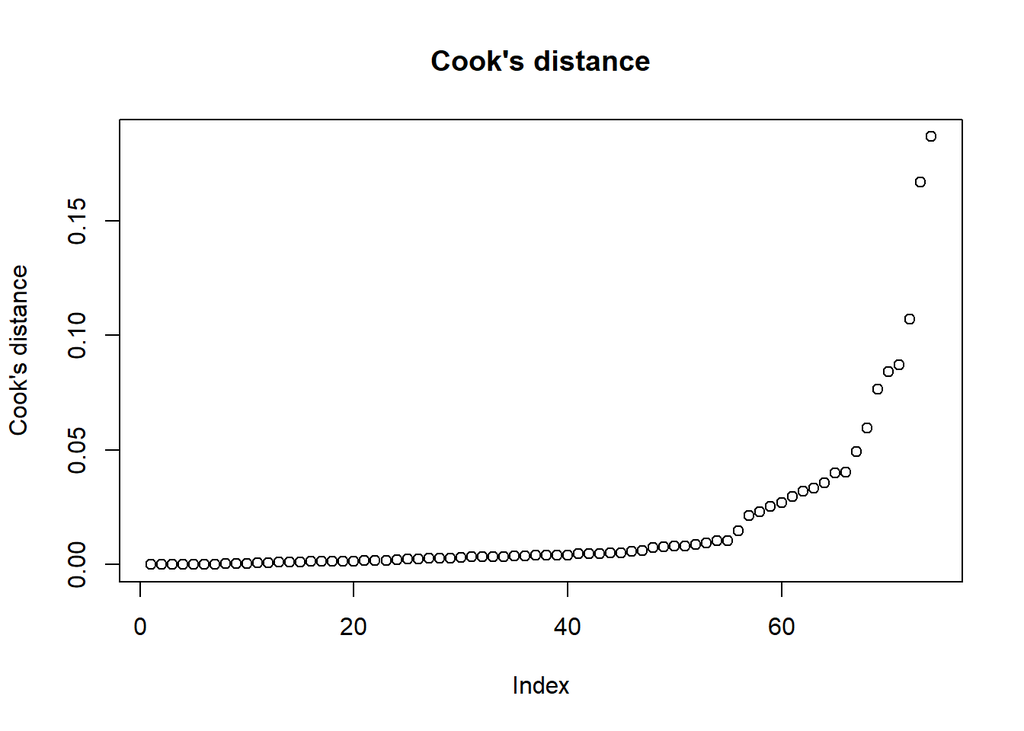

```
## [1] BOSTON   HONOLULU
## 75 Levels: AKRON ALBUQUER ANAHEIM ARLINGTO ATLANTA AURORA ... WICHITA
```

```
##    CRIME POVERT log_POPDEN log_BORN_F
## 20  9630   25.3   7.703459   3.152736
## 43 18394   31.2   9.240773   4.089332
```

Аутлаеры по Махаланобису. Рассмотим расстояние Махалонобиса до вектора средних по той же матрице в пространстве независимых признаков (не рассматриваем зависимый признак CRIME) (рассматриваем только оставшиеся признаки).

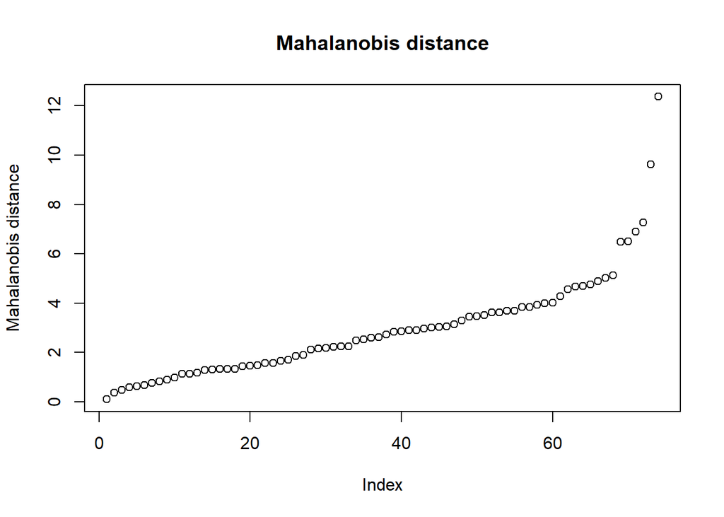

```
## [1] BOSTON   HONOLULU
## 75 Levels: AKRON ALBUQUER ANAHEIM ARLINGTO ATLANTA AURORA ... WICHITA
```

```
##    CRIME POVERT log_POPDEN log_BORN_F
## 20  9630   25.3   7.703459   3.152736
## 43 18394   31.2   9.240773   4.089332
```

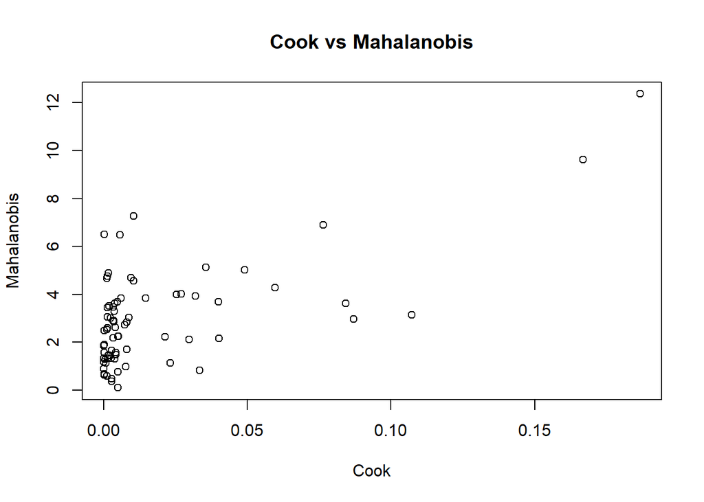

```r
plot(c.d,m.d,xlab = "Cook",ylab="Mahalanobis",main = "Cook vs Mahalanobis")
```

Рассмотрим модель без города с низким показателем POPDEN, так как хоть он и менее удален по обоим расстояниям, чем второй город, данный город мало вписывается в обычную модель.

```r
summary(model_final)
```

```
##
## Call:
## lm(formula = CRIME ~ POVERT + log_POPDEN + log_BORN_F, data = data.frame(subset(df_city,
##     !is.na(CRIME) & CITY != "BOSTON", select = -c(CITY, log_POP80,
##         INCOME))))
##
## Residuals:
##     Min      1Q  Median      3Q     Max
## -4320.7 -1292.2  -486.5  1273.6  6125.9
##
## Coefficients:
##             Estimate Std. Error t value Pr(>|t|)
## (Intercept)  13769.4     3695.9   3.726 0.000395 ***
## POVERT         297.3       51.8   5.739 2.33e-07 ***
## log_POPDEN   -1238.1      524.2  -2.362 0.021008 *
## log_BORN_F     697.1      369.4   1.887 0.063327 .
## ---
## Signif. codes:  0 '***' 0.001 '**' 0.01 '*' 0.05 '.' 0.1 ' ' 1
##
## Residual standard error: 2372 on 69 degrees of freedom
## Multiple R-squared:  0.3232, Adjusted R-squared:  0.2938
## F-statistic: 10.98 on 3 and 69 DF,  p-value: 5.549e-06
```

На самом деле почти ничего не изменилось.

## Итог

Построенная регрессия

```
##
## Call:
## lm(formula = CRIME ~ POVERT + log_POPDEN + log_BORN_F, data = subset(df_city,
##     !is.na(CRIME) & CITY != "BOSTON"))
##
## Residuals:
##     Min      1Q  Median      3Q     Max
## -4320.7 -1292.2  -486.5  1273.6  6125.9
##
## Coefficients:
##             Estimate Std. Error t value Pr(>|t|)
## (Intercept)  13769.4     3695.9   3.726 0.000395 ***
## POVERT         297.3       51.8   5.739 2.33e-07 ***
## log_POPDEN   -1238.1      524.2  -2.362 0.021008 *
## log_BORN_F     697.1      369.4   1.887 0.063327 .
## ---
## Signif. codes:  0 '***' 0.001 '**' 0.01 '*' 0.05 '.' 0.1 ' ' 1
##
## Residual standard error: 2372 on 69 degrees of freedom
## Multiple R-squared:  0.3232, Adjusted R-squared:  0.2938
## F-statistic: 10.98 on 3 and 69 DF,  p-value: 5.549e-06
```

$$\text{CRIME}=13769+297.3\,\text{POVERT}-1238.1\,\text{log_POPDEN} +697.1\,\text{log_BORN_F} .$$